# 01 - R framework with IMPACT - session 1

Author

Yann Say

Published

October 7, 2024

# IMPACT R framework

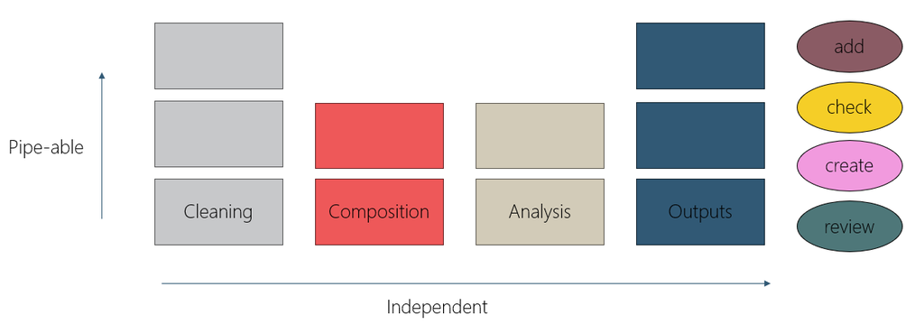

The IMPACT R framework has been developed to meet the requirements of the IMPACT research cycle.  
The ecosystem is a modular framework with two dimensions:

- a horizontal dimension that focuses on the outcome of a given step, and
- a vertical dimension that focuses on the content of a given step.

The framework is built around:

These elements will help to improve cooperation and collaboration between different teams while allowing modularity to adapt to each context and assessment.

# Cleaning - Checking a dataset

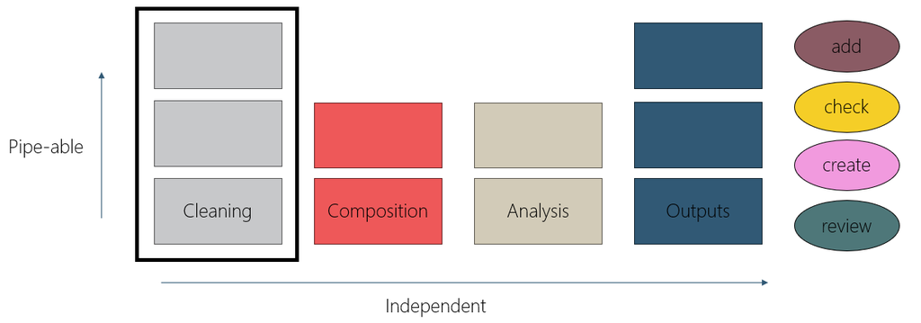

```r
library(cleaningtools)
library(dplyr)

my_raw_dataset <- cleaningtools::cleaningtools_raw_data
my_kobo_survey <- cleaningtools::cleaningtools_survey
my_kobo_choice <- cleaningtools::cleaningtools_choices
```

**check_**

**check_*** functions will flag values based on a specific check. It will return them in a log. A *check_** will return a list: the checked dataset, and the log.

**check_*** functions are used only in the cleaning step.

## check_outliers

```r
my_log1 <- my_raw_dataset %>%
  check_outliers(uuid_column = "X_uuid")
```

In this example, there are:

- `checked_dataset`: the raw dataset (with extra variables if needed)
- `potential_outliers`: a log of potential outliers

```r
typeof(my_log1)
```

```
[1] "list"
```

```r
my_log1 %>%
  names()
```

```
[1] "checked_dataset"    "potential_outliers"
```

The log has at least 4 columns:

- `uuid`: the unique identifier
- `issue`: the issue being flagged
- `question`: the name of the question
- `old_value`: the value being flagged

```r
my_log1$potential_outliers %>%
  head()
```

| uuid | issue | question | old_value |
| --- | --- | --- | --- |
| b5b1d37a-e27a-4c35-a0f5-2cde9d6dfd06 | outlier (normal distribution) | age_respondent_r | 86 |
| 956b5ed0-5a62-41b7-aec3-af93fbc5b494 | outlier (normal distribution) | age_respondent_r | 84 |
| 97ad6294-30c6-454e-a0b3-42126415b767 | outlier (log distribution) | age_respondent_r | 18 |
| e005e719-57c4-44a3-ac2f-5d6d1ff68831 | outlier (log distribution) | age_respondent_r | 18 |
| c9aaa542-118f-4e42-93de-fb0916572541 | outlier (normal distribution) | num_hh_member | 19 |
| 48e8896b-d1be-4600-8839-2d8b994ebcfb | outlier (normal distribution) | num_hh_member | 19 |

**Note**

Outliers are defined as +/- 3 standard deviation from the mean.

For log outliers, log(x + 1) is used.

## check_duplicate

```r
my_log2 <- my_raw_dataset %>%
  check_duplicate(uuid_column = "X_uuid")

my_log2$duplicate_log %>%
  head()
```

| uuid | old_value | question | issue |
| --- | --- | --- | --- |

There is no duplicate. The log is empty.

## Pipe-able

**Pipe-able**

The framework is built around 2 adjectives, **pipe-able** and **independent**. In the framework, functions of the same family should be pipe-able. In the following case, 2 **check_*** functions are piped.

```r
my_log3 <- my_raw_dataset %>%
  check_outliers(uuid_column = "X_uuid") %>%
  check_duplicate(uuid_column = "X_uuid")
```

```r
names(my_log3)
```

```
[1] "checked_dataset"    "potential_outliers" "duplicate_log"
```

```r
my_log3$potential_outliers %>%
  head()
```

| uuid | issue | question | old_value |
| --- | --- | --- | --- |
| b5b1d37a-e27a-4c35-a0f5-2cde9d6dfd06 | outlier (normal distribution) | age_respondent_r | 86 |
| 956b5ed0-5a62-41b7-aec3-af93fbc5b494 | outlier (normal distribution) | age_respondent_r | 84 |
| 97ad6294-30c6-454e-a0b3-42126415b767 | outlier (log distribution) | age_respondent_r | 18 |
| e005e719-57c4-44a3-ac2f-5d6d1ff68831 | outlier (log distribution) | age_respondent_r | 18 |
| c9aaa542-118f-4e42-93de-fb0916572541 | outlier (normal distribution) | num_hh_member | 19 |
| 48e8896b-d1be-4600-8839-2d8b994ebcfb | outlier (normal distribution) | num_hh_member | 19 |

```r
my_log3$duplicate_log %>%
  head()
```

| uuid | old_value | question | issue |
| --- | --- | --- | --- |

## More checks

This an example of more checks that exist.

```r
more_logs <- my_raw_dataset %>%
  check_duplicate(uuid_column = "X_uuid") %>%
  check_soft_duplicates(uuid_column = "X_uuid", kobo_survey = my_kobo_survey, sm_separator = ".") %>%
  check_outliers(uuid_column = "X_uuid") %>%
  check_value(uuid_column = "X_uuid")
```

## add_duration

**add_**

**add_*** functions will add a variable (column) to the dataset. For example, to add the duration of a survey, to add the food consumption score category, etc.

**add_*** function takes a dataset as input and returns the dataset + the new indicator (and any intermediate steps used for the calculation).

For example, to check the duration of a survey, there is only the start and end, but not the duration column.

```r
more_logs$checked_dataset <- more_logs$checked_dataset %>%
  add_duration(uuid_column = "X_uuid", start_column = "X.U.FEFF.start", end_column = "end")
more_logs$checked_dataset[1:6, c("start_date", "start_time", "end_date", "end_time", "days_diff", "duration")]
```

| start_date | start_time | end_date | end_time | days_diff | duration |
| --- | --- | --- | --- | --- | --- |
| 2021-07-05 | 658.57 mins | 2021-07-05 | 696.68 mins | 0 days | 38.11 |
| 2021-07-05 | 608.90 mins | 2021-07-05 | 641.92 mins | 0 days | 33.02 |
| 2021-07-05 | 682.23 mins | 2021-07-05 | 726.43 mins | 0 days | 44.20 |
| 2021-07-04 | 1342.98 mins | 2021-07-04 | 1380.15 mins | 0 days | 37.17 |
| 2021-07-04 | 1391.62 mins | 2021-07-05 | 18.88 mins | 1 days | 67.26 |
| 2021-07-05 | 617.38 mins | 2021-07-05 | 756.52 mins | 0 days | 139.14 |

**Warning**

The duration is added to the `checked_dataset` in the list, not in the `my_raw_dataset` dataframe. The **check_*** functions are used in a pipe, so it needs the current dataset to be modified.

**Warning**

At the moment, `add_duration` takes very specific format. It will change in the future to become more robust and using **lubridate**.

`check_duration` can now be used with the previous checks.

```r
more_logs <- more_logs %>%
  check_duration(column_to_check = "duration", uuid_column = "X_uuid")
```

As much as possible, **check_*** functions take default argument or the functions will be able to guess some information, e.g. the `check_outliers` function guesses some numerical values. Some functions need more information.

## other/text columns

`check_other` needs the list of columns to be checked. It currently, it cannot detect the open text question. KOBO tool can be used.

```r
other_columns_to_check <- my_kobo_survey %>%
  dplyr::filter(type == "text") %>%
  dplyr::filter(name %in% names(my_raw_dataset)) %>%
  dplyr::pull(name)

more_logs <- more_logs %>%
  check_others(uuid_column = "X_uuid", columns_to_check = other_columns_to_check)
```

## check_logical_with_list

In other cases, the check is specific and should be tailored to the dataset, for example, `check_logical_with_list`. All the logical checks can be recorded in an excel file.

```r
logical_check_list <- readxl::read_excel("inputs/01 - example - check_list.xlsx")
logical_check_list
```

[output not shown]

The check list has 4 columns:

- check_id : the name of the check
- description: the description of the check
- check_to_perform: the check to perform. The format for the check to be performed should take the format based on tidyverse. That format is as if a new indicator is create with a mutate. That new indicator should be a logical (i.e. TRUE or FALSE) with TRUE being the value to flag.

This list can then be used with `check_logical_with_list`.

```r
example_logic <- my_raw_dataset %>%
  check_logical_with_list(uuid_column = "X_uuid",
                          list_of_check = logical_check_list,
                          check_id_column = "check_id",
                          check_to_perform_column = "check_to_perform",
                          columns_to_clean_column = "columns_to_clean",
                          description_column = "description")
```

```r
example_logic$logical_all %>%
  head()
```

| uuid | question | old_value | issue | check_id | check_binding |
| --- | --- | --- | --- | --- | --- |
| f1175d29-ce1f-43a7-b3d1-ee26cd1b8cdb | primary_livelihood.employment | TRUE | primary_livelihood is employment but expenses less than 200000 | check_1 | check_1 <sub>/</sub> f1175d29-ce1f-43a7-b3d1-ee26cd1b8cdb |
| f1175d29-ce1f-43a7-b3d1-ee26cd1b8cdb | tot_expenses | 125000 | primary_livelihood is employment but expenses less than 200000 | check_1 | check_1 <sub>/</sub> f1175d29-ce1f-43a7-b3d1-ee26cd1b8cdb |
| e9f8b44c-c507-45a1-8d76-66d886437b8f | primary_livelihood.employment | TRUE | primary_livelihood is employment but expenses less than 200000 | check_1 | check_1 <sub>/</sub> e9f8b44c-c507-45a1-8d76-66d886437b8f |
| e9f8b44c-c507-45a1-8d76-66d886437b8f | tot_expenses | 175000 | primary_livelihood is employment but expenses less than 200000 | check_1 | check_1 <sub>/</sub> e9f8b44c-c507-45a1-8d76-66d886437b8f |
| 994a60b8-e640-425c-9774-160651d7af04 | primary_livelihood.employment | TRUE | primary_livelihood is employment but expenses less than 200000 | check_1 | check_1 <sub>/</sub> 994a60b8-e640-425c-9774-160651d7af04 |
| 994a60b8-e640-425c-9774-160651d7af04 | tot_expenses | 175000 | primary_livelihood is employment but expenses less than 200000 | check_1 | check_1 <sub>/</sub> 994a60b8-e640-425c-9774-160651d7af04 |

The log returns :

- uuid
- question: for all variables in **columns_to_clean**
- old value: for all variables in **columns_to_clean**
- issue
- check_id: logical check identifier
- check_binding: the combination of the check_id and the uuid.

One check can be flagged in several rows, in the example above, for each uuid, the primary_livelihood and tot_expenses are flagged.

Format for the **check_to_perform** should take the format based on *tidyverse*. That format is as if a new indicator is create with a `mutate`. That new indicator should be a logical (i.e. TRUE or FALSE) with TRUE being the value to flag.

```r
my_raw_dataset %>%
  dplyr::mutate(xxx =  primary_livelihood.employment == 1 & tot_expenses < 200000) %>%
  dplyr::select(X_uuid, xxx, primary_livelihood.employment, tot_expenses) %>%
  head()
```

| X_uuid | xxx | primary_livelihood.employment | tot_expenses |
| --- | --- | --- | --- |
| dcf2753a-6ea2-40f5-b493-3527931ef96c | FALSE | FALSE | 250000 |
| 8790ce5c-1c35-41a2-b3c0-538f937d5397 | FALSE | TRUE | 750000 |
| bb818e04-9c40-408e-919f-6b40ff1fdbb3 | FALSE | FALSE | 250000 |
| 28b90cbb-2cf0-41c5-9ee1-1c719c0d4c02 | FALSE | TRUE | 600000 |
| 7f2a0c6a-529b-481f-963f-a96dca2ec034 | FALSE | TRUE | 500000 |
| b4f92064-12ea-4970-b0f5-fd309de1dda3 | FALSE | FALSE | 650000 |

The checked dataset will be return with extra columns, i.e. a logical variable with the name of the **check_id**.

```r
example_logic$checked_dataset[1:6,tail(names(example_logic$checked_dataset))]
```

| X_notes | X_status | X_submitted_by | X_index | check_1 | check_2 |
| --- | --- | --- | --- | --- | --- |
| [] | submitted_via_web | reach_irq | 1 | FALSE | FALSE |
| [] | submitted_via_web | reach_irq | 2 | FALSE | FALSE |
| [] | submitted_via_web | reach_irq | 3 | FALSE | FALSE |
| [] | submitted_via_web | reach_irq | 4 | FALSE | FALSE |
| [] | submitted_via_web | reach_irq | 5 | FALSE | FALSE |
| [] | submitted_via_web | reach_irq | 6 | FALSE | FALSE |

**Note**

If you don’t include **columns_to_clean** the `check_logical_with_list` function will try to guess the variables. Not guarantee it will read or pick the correct names.

# Exercises

## Exercise 1

Try the following with a dataset:

- Perform a check to spot personal identifiable information

```r
library(cleaningtools)
library(dplyr)

my_raw_dataset <- cleaningtools::cleaningtools_raw_data
my_kobo_survey <- cleaningtools::cleaningtools_survey
my_kobo_choice <- cleaningtools::cleaningtools_choices
```

**Expand to get a hint**

Try the function `check_pii`

**Expand to get the answer**

```r
my_raw_dataset %>%
  check_pii(uuid_column = "X_uuid")
```

## Exercise 2

- Perform a check that will look at the percentages of missing value per observation and that will spot any observation that is *different*.

**Expand to get a hint**

Try the function `check_percentage_missing`

**Expand to get a hint**

Did you try to add a new column with `add_percentage_missing`

**Expand to get the answer**

```r
my_raw_dataset <- my_raw_dataset %>%
  add_percentage_missing(kobo_survey = my_kobo_survey)

my_raw_dataset %>%
  check_percentage_missing(uuid_column = "X_uuid")
```

Or if using a log already

```r
more_logs$checked_dataset <- more_logs$checked_dataset %>%
  add_percentage_missing(kobo_survey = my_kobo_survey)
more_logs %>%
  check_percentage_missing(uuid_column = "X_uuid")
```

## Exercise 3

- Fill the excel checklist to do the following checks:
  - household number (variable: **num_hh_member**) is above 8.
  - the water source for drinking water is bottled (variable: **water_source_drinking**, value: **bottled**) and the household always treat the drinking water (variable: **treat_drink_water**, value: **always_treat**).
  - the water source for drinking water is bottled (variable: **water_source_drinking**, value: **bottled**) and one of the main reason for the the household to not meet its water needs is the water pressure (variable: **access_water_enough_why_not**, value: **water_pressure**, this is a select multiple)

| name | label::English (en) | type |
| --- | --- | --- |
| num_hh_member | How many members are there in your household (including you)? | integer |
| water_source_drinking | What is the main source of water used by your household for drinking? | select_one water_sources |
| treat_drink_water | Does your household treat this water in any way to make it safer to drink? | select_one treat |
| access_water_enough_why_not | What are the main reasons your household is not able to meet its water needs? | select_multiple barriers_water_needs |

| name | label::English (en) | list_name |
| --- | --- | --- |
| bottled | Bottled or sachet water | water_sources |
| always_treat | Yes, always treat it before drinking | treat |
| water_pressure | Water pressure is not high enough/pumps required | barriers_water_needs |

```r
exercise_check_list <- readxl::read_excel("inputs/01 - example - check_list.xlsx")

my_raw_dataset %>%
    check_logical_with_list(uuid_column = "X_uuid",
                          list_of_check = exercise_check_list,
                          check_id_column = "check_id",
                          check_to_perform_column = "check_to_perform",
                          columns_to_clean_column = "columns_to_clean",
                          description_column = "description")
```

**Expand to get the answer**

```r
my_check_list <- data.frame(check_id = c("check_household number", "check_water_treatment", "check_3"),
                            description = c("num_hh_member is big","using bottled water and always treat","using bottled water and main reason is water pressure"),
                            check_to_perform = c("num_hh_member > 8","water_source_drinking == \"bottled\" & treat_drink_water == \"always_treat\"","water_source_drinking == \"bottled\" & access_water_enough_why_not.water_pressure == TRUE"),
                            columns_to_clean = c("num_hh_member","water_source_drinking, treat_drink_water","water_source_drinking, access_water_enough_why_not.water_pressure"))

my_raw_dataset %>%
    check_logical_with_list(uuid_column = "X_uuid",
                          list_of_check = my_check_list,
                          check_id_column = "check_id",
                          check_to_perform_column = "check_to_perform",
                          columns_to_clean_column = "columns_to_clean",
                          description_column = "description")
```

## Extra

- Try to add duration with audit files.

**Expand to get a tip**

Try `create_audit_list()` and `add_duration_from_audit()`